# General Regression: Ridge, Lasso, PCR & PLS

Pouria

4/18/2022

# Prompt

Looking at the `College` data set, we intend to predict the number of applications received, `Apps`, using the other variables.

1. Split the data set into a training set and a test set with 20% of the data held out as the test set.
2. Fit a PCR model on the training set, with M chosen by cross-validation. Report the test error obtained, along with the value of M selected by cross-validation.
3. Fit a PLS model on the training set, with M chosen by cross-validation. Report the test error obtained, along with the value of M selected by cross-validation.
4. Fit a linear model using least squares on the training set, and report the test error obtained.
5. Fit a ridge regression model on the training set, with $\lambda$ chosen by cross-validation. Report the test error obtained.
6. Fit a lasso model on the training set, with λ chosen by cross-validation. Report the test error obtained, along with the number of non-zero coefficient estimates.
7. Comment on the results obtained. How accurately can we predict the number of college applications received? Calculate test R-squared values. Is there much difference among the test errors resulting from these five approaches?

# Libraries

```r
library(ISLR)
library(glmnet)
library(pls)
library(ggplot2)
library(GGally)
library(dplyr)
library(tidyr)
```

# Set seed

- Set seed to `11`

# (a) Split the data

Split the data set into a training set and a test set. Hold 20% of the data out for test.

```r
train.size = round(dim(College)[1] *.8) # begin with setting the size of train set
```

# (b) Principal Component Regression (PCR) - Prompt

- Fit a PCR model on the training set, with number of PCs chosen by cross-validation. Visualize the results.
- Report the test error corresponding with the number of PCs selected from above.
- Report the variance explained in both predictors and response spaces across different number of PCs.

# (b) PCR

1. Perform PCR on the training set and visualize MSE across number of PCs using cross-validation.

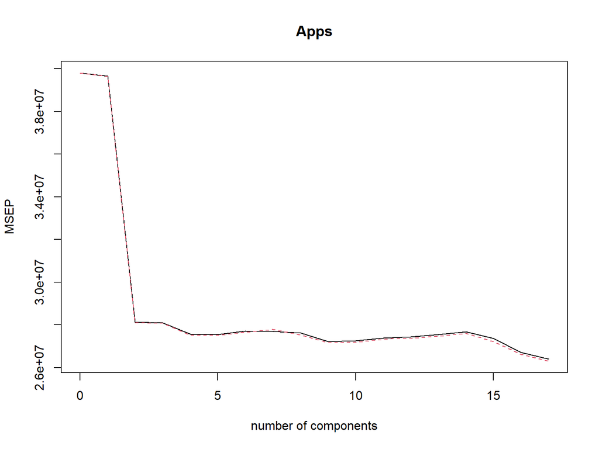

# (b) PCR

- Can you manually plot what `validationplot()` gave you above?

*Hint*: Look into `$validation$pred` and use index `[,1,]` to access the predictions per number of components. And remember you are working with a data frame so `apply()` can come in handy for any type of computation across different variables.

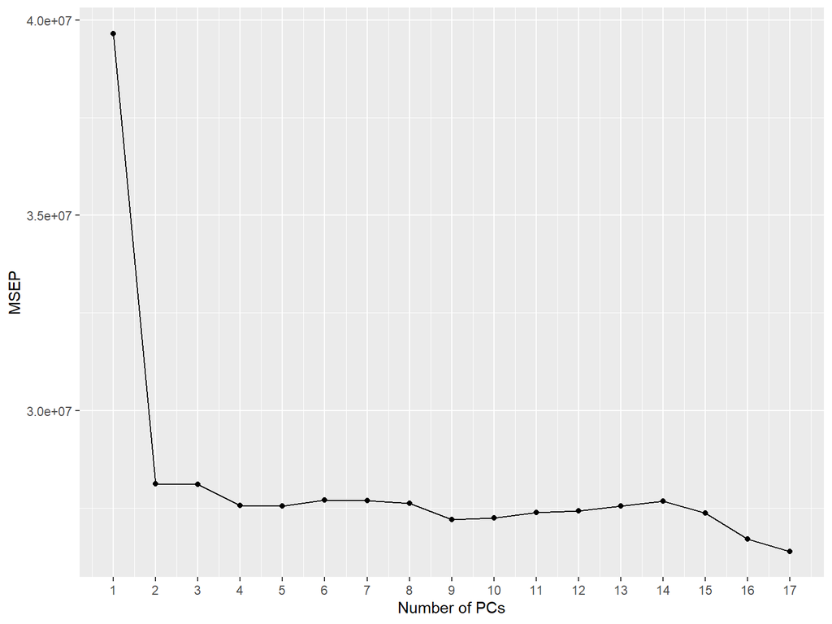

# (b) PCR

Use `selectNcomp()` to select the number of PCs that correspond to 1 SE.

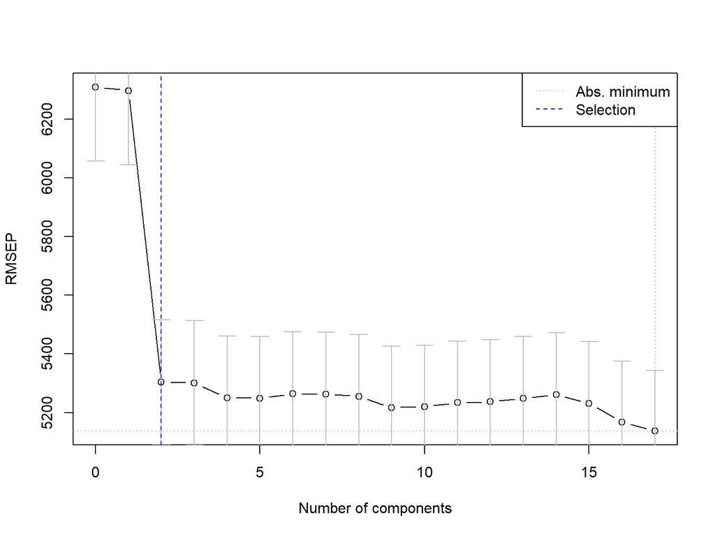

# (b) PCR

2. Report the test MSE for PCR with the number of PCs selected above.

# (b) PCR

3. Report a summary of the PCR model and visualize the variance explained in predictors space for different number of PCs.
- Summary

# (b) PCR

3. Report a summary of the PCR model and visualize the variance explained in both predictors and response variable spaces for different number of PCs.
- Visualize the variance explained

*Hint 1*: You may access the variance in predictors through `$Xvar`. Remember to use cumulative sum.

*Hint 2*: Also, `$residuals[,1,]` will give you the residuals for each number of PCs. Note that residuals and variance in response variable `Apps` are related. Variance explained in response variable space is the same as $R^2$.

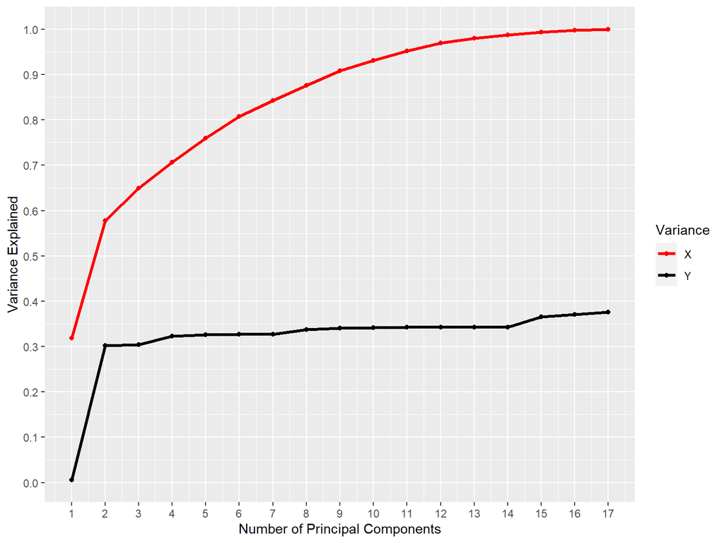

# (c) Partial Least Square Regression (PLSR) - Prompt

- Fit a PLS model on the training set, with number of components chosen by cross-validation.
- Report the test error obtained, along with the value of M selected by cross-validation.
- Report the variance explained in both predictors and response spaces across different number of PCs.

# (c) PLSR

1. Perform PLS on the training set and visualize MSE across number of components using cross-validation.

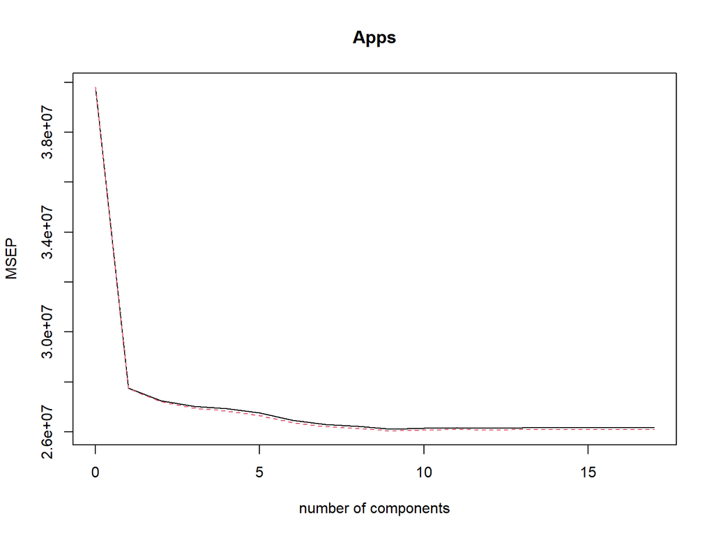

# (c) PLSR

- Plot manually

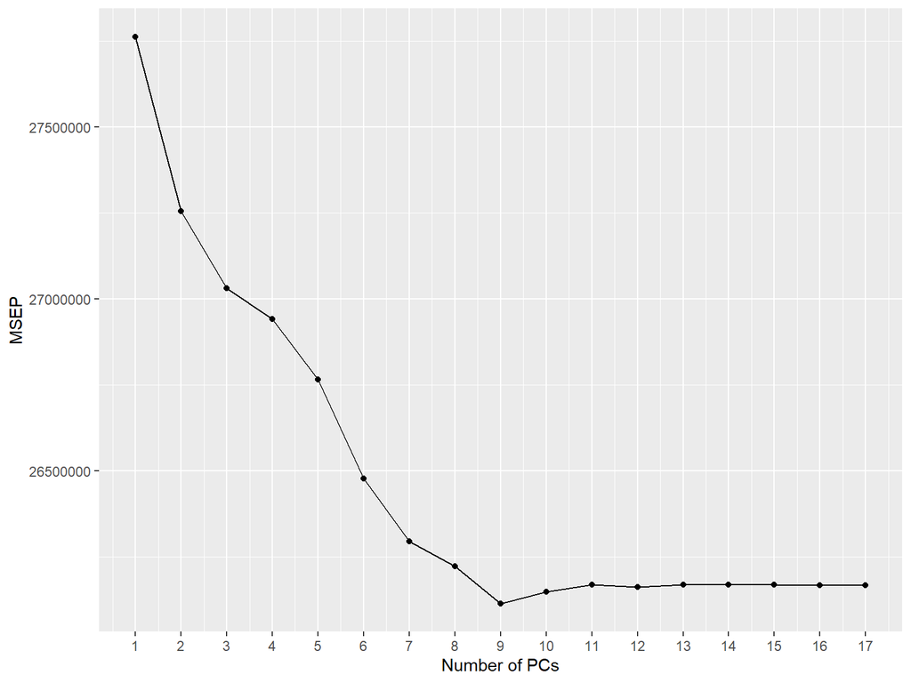

# (c) PLSR

Use `selectNcomp()` to select the number of PCs that correspond to 1 SE.

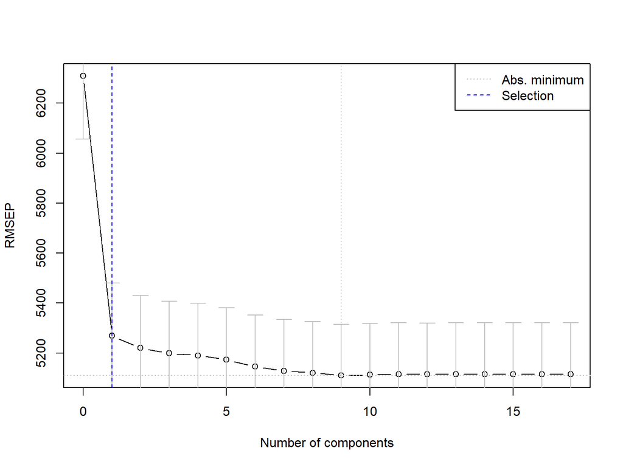

# (c) PLSR

2. Report the test MSE for PLS with the number of PCs selected above.

# (c) PLSR

3. Report a summary of the PCR model and visualize the variance explained in predictors space for different number of PCs.
- Summarize

# (c) PLSR

3. Report a summary of the PCR model and visualize the variance explained in both predictors and response variable spaces for different number of PCs.
- Visualize the variance explained

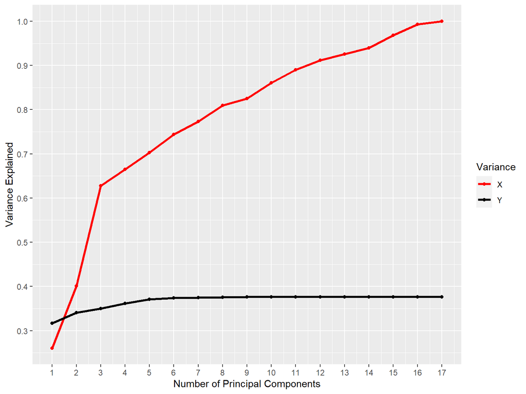

# (b) & (c)

Compare the results from PCR and PLS. How are the values and plots in (c) different from those obtained for PCR in (b). How can this difference be rationalized?

# (d) Fit a linear model

Fit a linear model using least squares on the training set, and report the test error obtained.

# (e) Ridge Regression - Prompt

- Fit a ridge regression model on the training set, with $\lambda$ chosen by cross-validation.
- Report the test error obtained.

# (e) Ridge Regression

1. First, turn the data into matrix to take care of categorical variables; One method to do this is `model.matrix` for both test and train sets. Note that this should be used for `cv.glmnet()`.

# (e) Ridge Regression

2. Now, Find the best $\lambda$.

# (e) Ridge Regression

3. Now, report the test error using Ridge with best $\lambda$.

# (f) Lasso Regression - Prompt

- Fit a lasso model on the training set, with $\lambda$ chosen by cross-validation.
- Report the test error obtained, …
  - along with the coefficients.

# (f) Lasso Regression

1. Now, Find the best $\lambda$.

# (f) Lasso Regression

2. Now, report the test error using Lasso with best $\lambda$.

# (f) Lasso Regression

3. Report the coefficients of the best Lasso model with best $\lambda$.

# (g) Compare Models - Prompt

Comment on the results obtained.

- How accurately can we predict the number of college applications received?
- Is there much difference among the test errors resulting from these five approaches? Visualize using bar-plots.
- Calculate test R-squared values and compare. Visualize using bar-plots.

# (g) Compare Models

1. Is there much difference among the test errors resulting from these five approaches? Visualize using bar-plots.

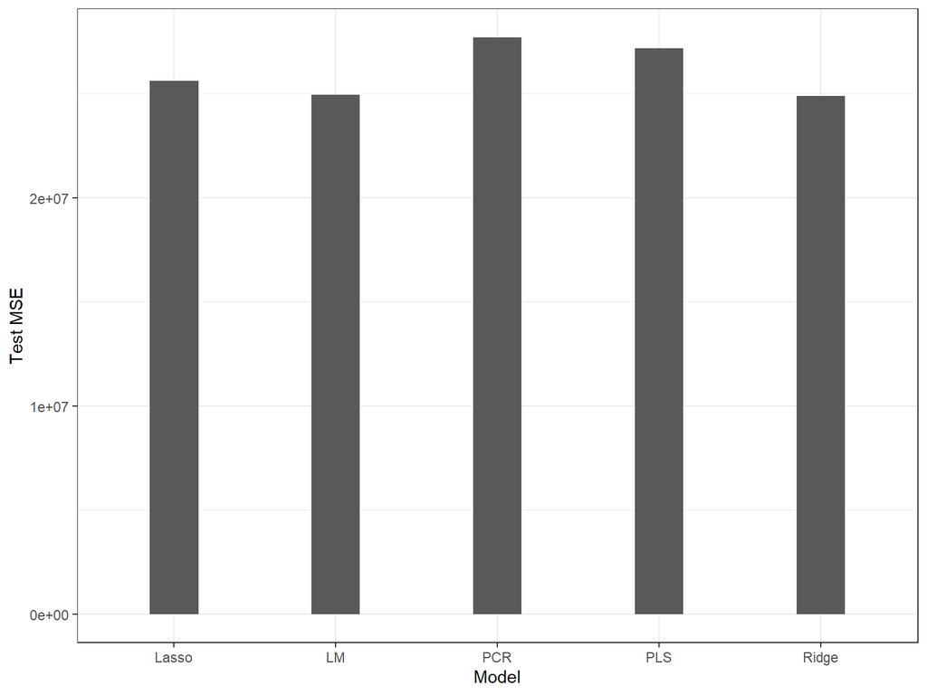

# (g) Compare Models

2. Calculate test R-squared values and compare. Visualize using bar-plots.

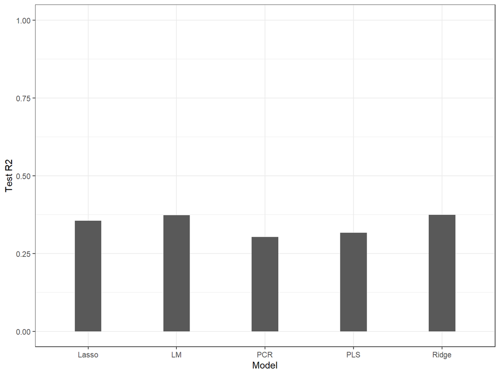